# Assignment-1-Network-analysis

Mathias Flinta

11/10/2019

# 1 Introduction and set-up

In this assignment i will analyze a network from 21 managers of a high-tec company in the US. Each manager was asked to whom do you go to for **advice** and who is your **friend**, to whom do you **report** was taken from company documents. I will explain further about the variables when it’s being analyzed.

This project is made to be read in html, so open the html file in your preferred webbrowser. As standard the code is hidden in this document, but you can show all by pressing the button “Code” in the top right of the document. You can also show individual chunks of code by pressing the buttons “Code” which are placed around in the document.

Link for google colab: https://colab.research.google.com/drive/1qnHPYpBX9NlpWdvFfNC5VTdS5qiv9Dat

Link for github (backup for download): https://github.com/DataEconomistDK/SDS-M2-Mini1

First i have some personal setup in my local R-Markdown on how i want to display warnings ect. And then i load my packages.

```r
### Knitr options
knitr::opts_chunk$set(warning=FALSE,
                     message=FALSE,
                     fig.align="center"
                     )

options(warn=-1) # Hides all warnings, as the knitr options only work on local R-Markdown mode.

Sys.setenv(LANG = "en")
```

```r
# Packages
library(knitr) # For knitr to html
library(rmarkdown) # For formatting the document
library(tidyverse) # Standard datasciewnce toolkid (dplyr, ggplot2 et al.)
library(data.table) # for reading in data ect.
library(magrittr) # For advanced piping (%>% et al.)
library(igraph) # For network analysis
library(tidygraph) # For tidy-style graph manipulation
library(ggraph) # For ggplot2 style graph plotting
library(Matrix) # For some matrix functionality
library(ggforce) # Awesome plotting
library(kableExtra) # Formatting for tables
library(car) # recode functions

# I set a seed for reproduciability
set.seed(123) # Have to be set every time a rng proces is being made.
```

# 2 Creating the network

## 2.1 Loading the data

First we will load the data into R. I also rename the column names for the edge list.

```r
node_attributes <- fread("https://raw.githubusercontent.com/SDS-AAU/M2-2019/master/notebooks/assignments/assignment_1/data/Krack-High-Tec-Attributes.csv")

edge_advice_raw <- fread("https://raw.githubusercontent.com/SDS-AAU/M2-2019/master/notebooks/assignments/assignment_1/data/Krack-High-Tec-edgelist-Advice.txt")

edge_friendship_raw <- fread("https://raw.githubusercontent.com/SDS-AAU/M2-2019/master/notebooks/assignments/assignment_1/data/Krack-High-Tec-edgelist-Friendship.txt")

edge_reports_to_raw <- fread("https://raw.githubusercontent.com/SDS-AAU/M2-2019/master/notebooks/assignments/assignment_1/data/Krack-High-Tec-edgelist-ReportsTo.txt")

Column_names <- c("from", "to", "edge")

colnames(edge_advice_raw) <- Column_names
colnames(edge_friendship_raw) <- Column_names
colnames(edge_reports_to_raw) <- Column_names
```

To get an understanding of the scope and structure of the data i get the dimensions of the edges of the advice data. It has 3 columns. Column 1 is the “from ID”, column 2 is the “to ID” and column 3 is the binary nr. indicating the presence (=1) or absence (=0) of an edge. And it has 21x21=441 rows.

```r
dim(edge_advice_raw)
```

```
## [1] 441   3
```

In this case we need to do further preperation with the edge list, as we need to format it so that the row only exists if column 3 indicates presence of a connection. Otherwise all further analysis will just interpret it as every vertex being connected, as it does not read the third column. Therefore i filter all three edge lists, so that i remove rows where no edge exist.

```r
edge_advice <- edge_advice_raw %>%
  filter(edge == 1)

edge_friendship <- edge_friendship_raw %>%
  filter(edge == 1)

edge_reports_to <- edge_reports_to_raw %>%
  filter(edge == 1)
```

## 2.2 From edgelist to network

I create my three networks from the 3 edge lists: reports to, friendship and advice, and attaching the node attributes to each network. I have here decided to use the tbl_graph class, which is a thin wrapper around the igraph object. Here we can still use all the igraph function, but also apply the tidy methods.

```r
g_advice <- tbl_graph(edges = edge_advice, nodes = node_attributes, directed = TRUE)
g_friendship <- tbl_graph(edges = edge_friendship, nodes = node_attributes, directed = TRUE)
g_reports_to <- tbl_graph(edges = edge_reports_to, nodes = node_attributes, directed = TRUE)
```

So now we have 3 different directed, unweighted networks, each displaying 3 different sides/perspectives of the same underlying relations between the 21 managers.

# 3 Analysis

## 3.1 A: Network level characteristics

When working with network, it can be beneficial to analyze the network as a whole, before further specific analysis. To start of i do a plot off all three networks together, just to get a impression of how the networks are. Then i will calculate 3 key metrics: Density, transistivity, reciprocity for all 3 networks. These a key figures that can indicate more precisly the nature of the network. Then i will use this to answer the questions about the networks.

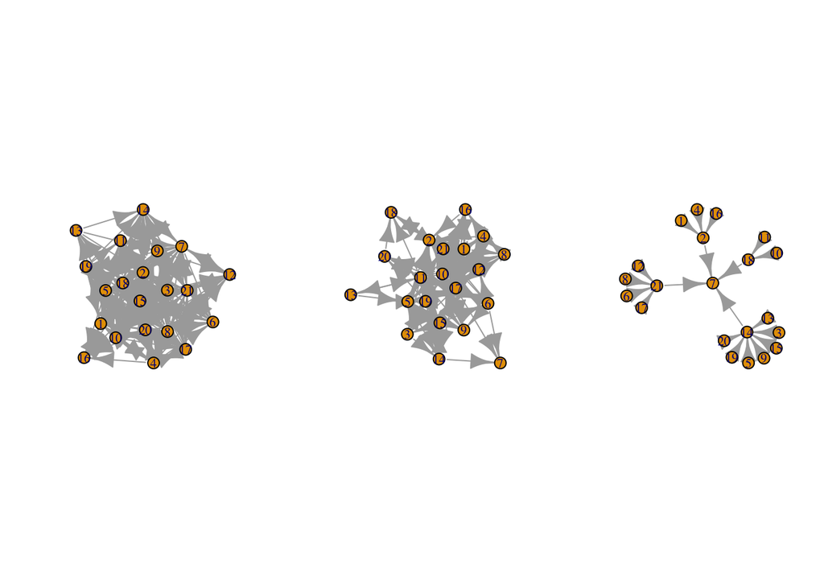

```r
par(mfrow=c(1,3))
set.seed(123)
plot(g_advice)
set.seed(123)
plot(g_friendship)
set.seed(123)
plot(g_reports_to)
```

Just based on these plots, we can see some patterns. For the first graph (on the left) based on the question, “to whom do you go to for **advice**”, we see that most managers go to several other managers for advice, indicated by the many edges. For the second graph (in the middle) based on the question “who is your **friend**?”, we see less edges than before. We also see that all managers have at least one friend, and it seems like most have a couple of friends. Also we see that it does not always go both ways indicated by the arrow in only one direction. The third graph (on the right) based on the question, “to whom do you **report**” was taken from company documents, and here we see very few edges. All managers only reports to one other manager, indicating the chain of command in the company, leading up to one manager in the middle being the CEO. Now i will use the key figures from the below table to get further insights.

```r
# Edge density
advice_density <- edge_density(g_advice)
friendship_density <- edge_density(g_friendship)
reports_to_density <- edge_density(g_reports_to)
# Transitivity
advice_trans <- transitivity(g_advice)
friendship_trans <- transitivity(g_friendship)
reports_to_trans <- transitivity(g_reports_to)
# Reciprocity
advice_reci <- reciprocity(g_advice)
friendship_reci <- reciprocity(g_friendship)
reports_to_reci <- reciprocity(g_reports_to)
# I make a matrix of the key metrics
key_metrics_vector <- c(advice_density, friendship_density, reports_to_density,
                 advice_trans, friendship_trans, reports_to_trans,
                 advice_reci, friendship_reci, reports_to_reci)
key_metrics_m <- matrix(round(key_metrics_vector, 3), 3, 3, byrow = TRUE)
# I give the matrix names
colnames(key_metrics_m) <- c("Advice", "Friendship", "Reports to")
rownames(key_metrics_m) <- c("Edge density", "Transitivity", "Reciprocity")
# I format it nicely in a table
kable(key_metrics_m) %>%
  kable_styling(bootstrap_options = "striped", full_width = F, position = "float_right") %>%
  add_header_above(header = c("Key metrics" = 4))
```

| Key metrics | Key metrics Advice | Key metrics Friendship | Key metrics Reports to |
| --- | --- | --- | --- |
| Edge density | 0.452 | 0.243 | 0.048 |
| Transitivity | 0.735 | 0.471 | 0.000 |
| Reciprocity | 0.474 | 0.451 | 0.000 |

Edge density describes the portion of the potential connections in a network that are actual connections. For the advice network we see that the edge density is at 0.452, which means that the managers on average ask almost 50% of the other managers for advice. The friendship network the edge density is at 0.243, which means that the managers on average are friends with about 25% of the other managers. The reports to network have a edge density at 0.048, which is very low and indicates that there is only one chain of command. So overall we see that employess are more likely to have a advice-seeking relationsship than a friendship.

Transistivity, also called the clustering coefficient. It measures the proportion of all possible triangles in the network that are closed. Triangles is if a edge exists between three given vertices. For the advice network we see it’s at 0.735, which is a quite interlinked network. This indicates that there are many small teams or cliques that gives each other advice. For the friendship network we see it’s at 0.471, which is still quite interlinked, though still less than the advice network. This also indicates that there is some groups of friends within the company.

Reciprocity measures the likelihood of vertices in a directed network to be mutually linked. For the advice network we see it’s at 0.474, indicating that about 47% of managers get advice from the same managers they ask for advice. For the friendship network we see almost the same level of reciprocity at 0.451, which states that only 45% of managers have indicated other managers as friends, where that managers have indicated him as a friend aswell. This means that 55% of managers does not have mutual friendships, when asked for in this survey. Overall we could say that relationsships like friendship and advice are not likely to be reciprocal, as they are both less than 50%. Off course this might be caused by the respondents defining friendsship in different ways, but here we must read the research paper to get further insights to this. Reciprocity for the reports to network is 0%, as the chain of command only goes in one direction.

## 3.2 B: Node level characteristics

To figure out who is the most popular i calculate the degree of incoming edges in the 2 networks friendship and advice. These can be said to be the most wanted friend or advicer.

```r
g_advice_in <- degree(g_advice, mode = c("in"))
g_friendship_in <- degree(g_friendship, mode = c("in"))

# I make the data matrix with the most popular
popular_vector <- c(max(g_advice_in), max(g_friendship_in), which.max(g_advice_in), which.max(g_friendship_in))
popular_m <- matrix(popular_vector, 2, 2, byrow = TRUE)

# I give the matrix names
colnames(popular_m) <- c("Most popular advicer", "Most popular friend")
rownames(popular_m) <- c("Nr. of connections", "ID nr.")
# I format it nicely in a table
kable(popular_m) %>%
  kable_styling(bootstrap_options = "striped", full_width = F, position = "float_right") %>%
  add_header_above(header = c("Who haves the most incoming degrees?" = 3))
```

| Who haves the most incoming degrees? | Who haves the most incoming degrees? Most popular advicer | Who haves the most incoming degrees? Most popular friend |
| --- | --- | --- |
| Nr. of connections | 18 | 10 |
| ID nr. | 2 | 2 |

In this case we see that the most popular advicer and friend is the same persion with the ID nr. 2. This manager has 18 people asking him advice and 10 people consider him their friend. This is quite a lot in a network of 21 managers.

To answer if managers in higher hirarchy are more popular as friend, and advice giver, i take the in degree calculations from before, and calculate a mean based on each level of corporate hierarchy (coded 1,2 and 3; 1 = CEO, 2 = Vice President, 3 = manager).

```r
node_att_degree <- as_tibble(cbind(node_attributes, g_advice_in, g_friendship_in))

hierarchy_stats <- node_att_degree %>%
  group_by(LEVEL) %>%
  summarise("mean advice" = mean(g_advice_in),
            "mean friendship" = mean(g_friendship_in))

kable(hierarchy_stats) %>%
  kable_styling(bootstrap_options = "striped", full_width = F, position = "float_right") %>%
  add_header_above(header = c("Incoming degrees" = 3))
```

| Incoming degrees LEVEL | Incoming degrees mean advice | Incoming degrees mean friendship |
| --- | --- | --- |
| 1 | 13.0000 | 3.0000 |
| 2 | 14.5000 | 6.0000 |
| 3 | 7.4375 | 4.6875 |

In the table we see that it’s not a one-sided case. Level 2 (the vice-presidents) are the ones ask the most for advice, and also most people consider them friends. Level 1 (the CEO) are actually asked a little less for advice than level 2, and they have half the amount of people who consider them friends. Level 3 (the managers) are not asked that often for advice compared to the others levels, but they have a decent amount of people who consider them friends.

## 3.3 C: Relational Characteristics

To answer these relational questions, we can look at assortativity which is a measure of how preferentially attached vertices are to other vertices with identical attributes. Now we will look into several different attributes and see if they create a preference to become friends og give advice. I here create a table with the assortativity coefficients for the 2 different networks and the 4 different attributes.

```r
# Department
ass_adv_dep <- assortativity(g_advice, V(g_advice)$DEPT, directed = TRUE)
ass_friend_dep <- assortativity(g_friendship, V(g_friendship)$DEPT, directed = TRUE)
# Hierarchy
ass_adv_hier <- assortativity(g_advice, V(g_advice)$LEVEL, directed = TRUE)
ass_friend_hier <- assortativity(g_friendship, V(g_friendship)$LEVEL, directed = TRUE)
# Age
ass_adv_age <- assortativity(g_advice, V(g_advice)$AGE, directed = TRUE)
ass_friend_age <- assortativity(g_friendship, V(g_friendship)$AGE, directed = TRUE)
# Tenure
ass_adv_tenure <- assortativity(g_advice, V(g_advice)$TENURE, directed = TRUE)
ass_friend_tenure <- assortativity(g_friendship, V(g_friendship)$TENURE, directed = TRUE)

# Creating fancy matrix
assortativity_vector <- c(ass_adv_dep, ass_friend_dep, ass_adv_hier, ass_friend_hier, ass_adv_age, ass_friend_age, ass_adv_tenure, ass_friend_tenure)

assortativity_m <- matrix(round(assortativity_vector, 4), 4, 2, byrow = TRUE)

# I give the matrix names
colnames(assortativity_m) <- c("Advice", "Friendship")
rownames(assortativity_m) <- c("Department", "Hierarchy", "Age", "Tenure")
# I format it nicely in a table
kable(assortativity_m) %>%
  kable_styling(bootstrap_options = "striped", full_width = F, position = "float_right") %>%
  add_header_above(header = c("Assortativity" = 3))
```

| Assortativity | Assortativity Advice | Assortativity Friendship |
| --- | --- | --- |
| Department | 0.1076 | 0.1512 |
| Hierarchy | 0.0554 | 0.2592 |
| Age | 0.0388 | 0.1003 |
| Tenure | 0.1552 | -0.0946 |

From the table we see that in general there is a positive correlation for the different attributes and giving advice and being friends. There is different noteworthy relations. If you are in the same department you share more advice and are more likely to become friends. This makes great sence, as people in the same department are likely to spend more time together and work on the same projects. People in the same hierarchy do only share a little extra advice, but a way more likely to become friends. People of the same age gives a little extra advice, and extra inclined to become friends. People of same tenure(experience), are more likely to share advice, but for tenure we see that people of same experience are not as likely to become friends as others. This negative coefficient is a weird finding.

# 4 Aggregated networks

To create a aggregated network where nodes are departments, we need to remake the edgelist. To do so i first create a double for loop, with a IF statements that transforms the ID in the from and to column to the department nr. into new columns, for the 2 raw edge files. Then i bind them together into one edge.

```r
edge_advice_raw$from_dept <- NA
for (i in 1:441) {
  for (j in 1:21) {
    if (edge_advice_raw$from[i] == node_attributes$ID[j]) {
      edge_advice_raw$from_dept[i] <- node_attributes$DEPT[j]
      break }}}

edge_advice_raw$to_dept <- NA
for (i in 1:441) {
  for (j in 1:21) {
    if (edge_advice_raw$to[i] == node_attributes$ID[j]) {
      edge_advice_raw$to_dept[i] <- node_attributes$DEPT[j]
      break }}}

edge_friendship_raw$from_dept <- NA
for (i in 1:441) {
  for (j in 1:21) {
    if (edge_friendship_raw$from[i] == node_attributes$ID[j]) {
      edge_friendship_raw$from_dept[i] <- node_attributes$DEPT[j]
      break }}}

edge_friendship_raw$to_dept <- NA
for (i in 1:441) {
  for (j in 1:21) {
    if (edge_friendship_raw$to[i] == node_attributes$ID[j]) {
      edge_friendship_raw$to_dept[i] <- node_attributes$DEPT[j]
      break }}}

edge_dept_raw <- bind_rows(edge_advice_raw, edge_friendship_raw)
```

As i used the raw edge files i need to do some filtering again. I filter away rows where edge = 0, which means no edge exist. Then i remove all columns except the from_dept and the to_dept. Now i just need to remove all edges that are intra department, so that i only have cross department edges. Finally i am left with 208 edges between the departments. It can be argued that department 0, which is the CEO department should be removed, but i find it a bit interesting so i leave it in here.

```r
edge_dept <- edge_dept_raw %>%
  filter(edge == 1) %>%
  select(from_dept, to_dept) %>%
  filter(from_dept != to_dept)
```

Now i create the graph object. The node names are automatically created from the edgelist.

```r
g_dept <- edge_dept %>% as_tbl_graph(directed = TRUE)
g_dept
```

```
## # A tbl_graph: 5 nodes and 208 edges
## #
## # A directed multigraph with 1 component
## #
## # Node Data: 5 x 1 (active)
##   name
##   <chr>
## 1 4
## 2 2
## 3 0
## 4 1
## 5 3
## #
## # Edge Data: 208 x 2
##    from    to
##   <int> <int>
## 1     1     4
## 2     1     5
## 3     1     4
## # … with 205 more rows
```

Now i plot the graph object. As you can see, when there is only 5 nodes and 208 edges, representing cross department advice/friendship, then there is many edges between nodes. I have plotted the edges with a bend, so it’s more easy to see all of the edges. There is many edges between the 4 main departments (1,2,3,4), which can be seen from the wide edge connections. In general there is only a few edges to the CEO department (0), but with big differences. From the CEO to department 1 and 2 there is several edges, but with department 3 and 4 , there only seems to be one edge.

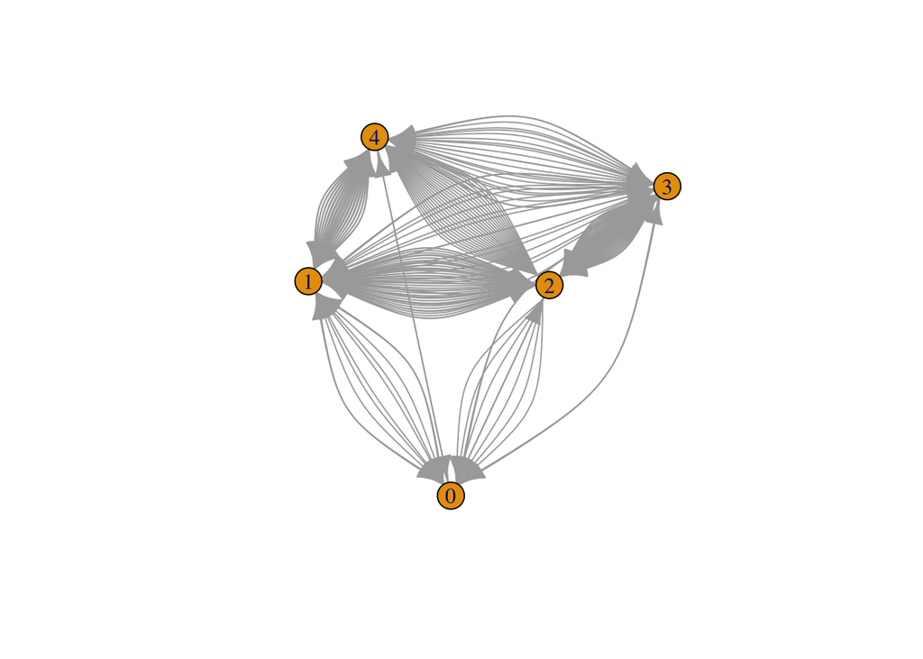

```r
set.seed(123)
plot(g_dept,
     edge.arrow.size = 1)
```

# 5 Visualization

For this final task, i want to visualize the two graph networks with advice and friendship, and highlight key variables to get new insights.

Based on the previous analysis, it seemed that there in general was a great difference between the degrees for in and out. This was also indicated by reciprocity only being about 45%-47% for these two networks. To get further insights i calculated the difference between in and out degress for all nodes in the two networks. So a positive value indicates more in, than out degress and the opposite for negative values.

```r
g_advice_in <- degree(g_advice, mode = c("in"))
g_advice_out <- degree(g_advice, mode = c("out"))
degree_difference_advice <- g_advice_in-g_advice_out

g_friendship_in <- degree(g_friendship, mode = c("in"))
g_friendship_out <- degree(g_friendship, mode = c("out"))
degree_difference_friendship <- g_friendship_in-g_friendship_out
```

I then calculate the **Eigenvector centrality**. This metric weights a node’s degree centrality by the centrality of the nodes adjacent to it, and their centrality in turn by their centrality.

```r
g_advice_cent <- g_advice %N>%
  mutate(centrality_eigen = centrality_eigen(directed = TRUE, scale = TRUE),
         degree_difference = degree_difference_advice)

g_friendship_cent <- g_friendship %N>%
  mutate(centrality_eigen = centrality_eigen(directed = TRUE, scale = TRUE),
         degree_difference = degree_difference_friendship)
```

Now i plot the two different networks based on these calculated variables. The degree difference is plotted as a continous color variable for the nodes. Here very green values indicates the relative most popular managers, as they have the most in degrees compared to out degrees. The eigen centrality is plotted as the size of the nodes. The levels of hierarchy are plotted are plotted as the shapes of the nodes. The arrows indicate direction.

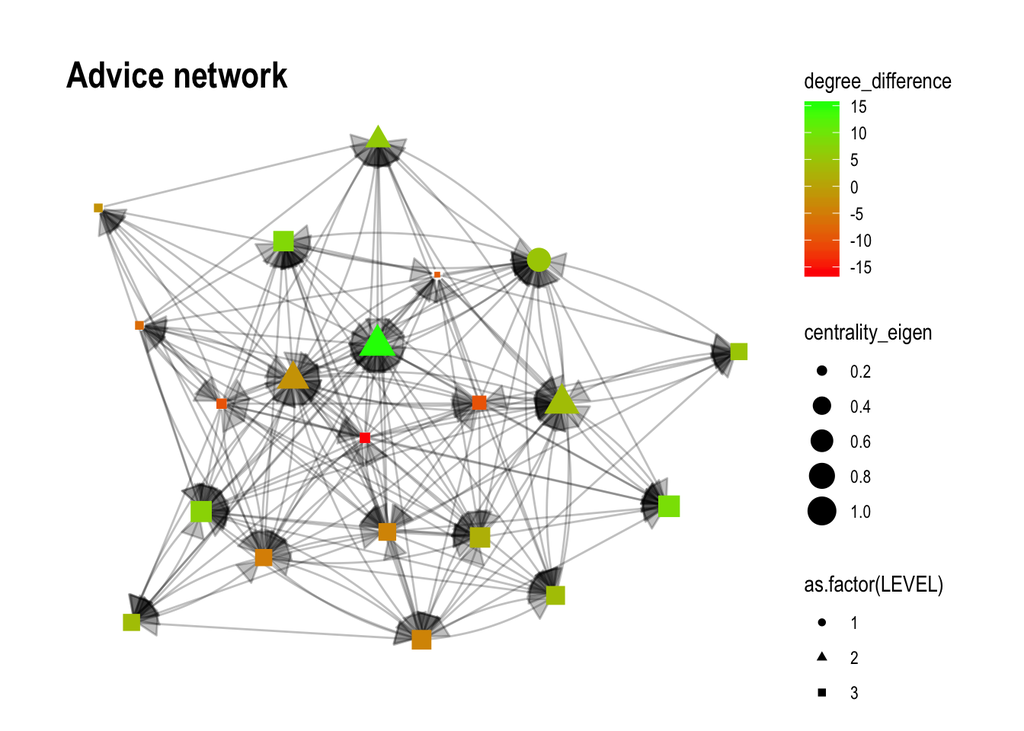

```r
set.seed(123)
g_advice_cent %>%
  ggraph(layout = 'nicely') +
  geom_edge_fan(aes(), alpha = 0.25,
                arrow = arrow(type = "closed", length = unit(4, "mm")),
                start_cap = circle(1, "mm"),
                end_cap = circle(1, "mm")
                ) +
  geom_node_point(aes(size = centrality_eigen,
                    color = degree_difference,
                    shape = as.factor(LEVEL)),
                  show.legend = TRUE) +
  scale_colour_gradient(low = "red", high = "green") +
  theme_graph() +
  ggtitle("Advice network")
```

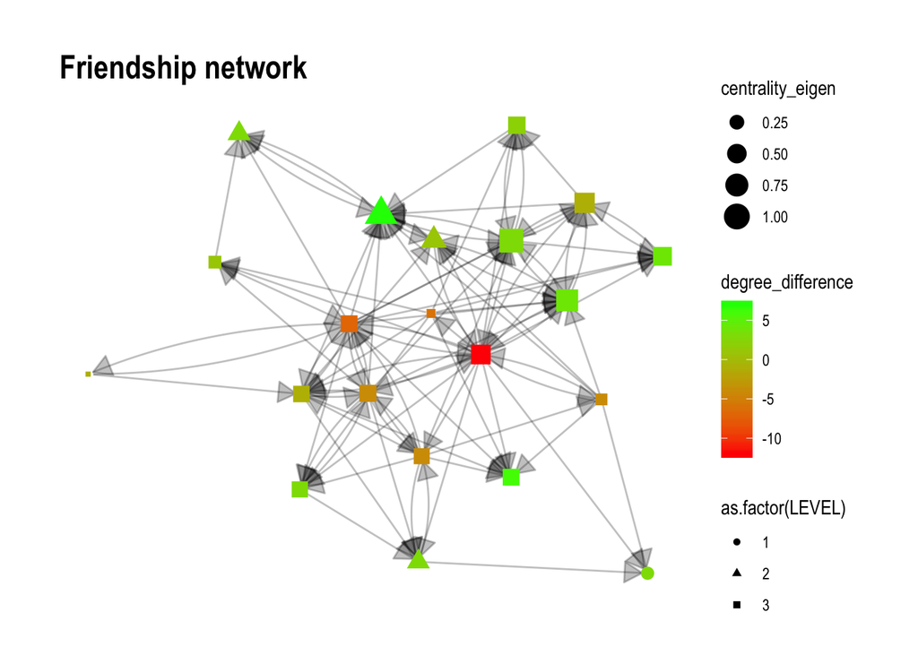

```r
set.seed(123)
g_friendship_cent %>%
  ggraph(layout = 'nicely') +
  geom_edge_fan(aes(), alpha = 0.25,
                arrow = arrow(type = "closed", length = unit(4, "mm")),
                start_cap = circle(1, "mm"),
                end_cap = circle(1, "mm")
                ) +
  geom_node_point(aes(size = centrality_eigen,
                    color = degree_difference,
                    shape = as.factor(LEVEL)),
                  show.legend = TRUE) +
  scale_colour_gradient(low = "red", high = "green") +
  theme_graph() +
  ggtitle("Friendship network")
```

In general for both networks, we see that the managers in the lowest hierarchical levels (the squares), seems to have the most negative degree difference (indicated by the red color). This tells us that they ask more questions than they are asked, which indicates that they go to their superior for help and advice, and they themselves are not asked for advice. For the friendship network this tells us that people often tend to see their superiors as friends, but the superiors does not see the managers below in the hierarchy as friends in the same way.